# 1️⃣ Table of Contents

1. Environment Setup & Data Loading
2. Data Overview & Quality Checks
3. Q1 — Which hour has the highest frequency of crimes?
4. Q2 — Which area has the highest frequency of night crimes?
5. Q3 — How does crime distribution vary by victim age group?
6. Q4 — What are the top 5 most common crime types?
7. Q5 — How does crime distribution vary by victim gender?
8. Q6 — Which area experiences the highest number of crimes during peak crime hours?
9. Q7 — How do crime patterns differ between weekdays and weekends?
10. Q8 — Which weekday has the highest crime frequency?
11. Q9 — How does crime distribution vary by victim descent and gender?
12. Q10 — How does weapon involvement vary across crime types?
13. Appendix

# 2️⃣ Crime Analysis in Los Angeles (2020–2023): A Data Analytics Case Study

- **Author:** Andreza Eufrasio
- **Tools:** Python, Pandas, Matplotlib, Seaborn
- - **File:** `data/crimes.csv`
- **Dataset Source:** DataCamp (educational)
- **Description:**

This dataset contains reported crime incidents in Los Angeles from January 1, 2020 to July 3, 2023. Each record represents a single crime event and includes information about the type of crime, location, date and time of occurrence, and victim characteristics such as age, gender, and descent.

The dataset also provides details on weapon involvement and reporting information, enabling analysis of crime patterns across time, geography, and demographics.

This version of the dataset has been adapted for educational purposes from the original Los Angeles Open Data portal.

It supports exploratory and statistical analysis of crime trends, providing insights into high-risk areas, temporal patterns, and victim demographics.

# 3️⃣ Introduction

[figure not shown]

Los Angeles, California 🌴 — often known as the “City of Angels” and a global hub for entertainment — is one of the largest and most dynamic cities in the United States.

With its large population and geographic diversity, Los Angeles experiences a wide range of criminal activity. Understanding these patterns is essential for improving public safety and optimizing resource allocation.

In this case study, you have been tasked with supporting the Los Angeles Police Department (LAPD) by analyzing crime data to identify key trends in criminal behavior. The goal is to generate actionable insights that can support data-driven decision-making, enabling more effective allocation of police resources and targeted crime prevention strategies.

# 4️⃣ Objective:

Analyze crime patterns in Los Angeles between January 1, 2020 and July 3, 2023, with a focus on:

- identifying the most common crime types
- analyzing areas with the highest crime frequency
- examining temporal patterns (hour, weekday vs weekend)
- exploring victim demographics
- assessing weapon involvement

# 5️⃣ The Data

They have provided you with a single dataset to use. A summary and preview are provided below.

## Data Dictionary: `crimes`

### File: `crimes.csv`

| Column | Type | Description |
| --- | --- | --- |
| `dr_no` | integer | Division of Records Number: official file number composed of year, area ID, and unique digits. |
| `date_rptd` | datetime | Date the crime was reported. |
| `date_occ` | datetime | Date the crime occurred. |
| `time_occ` | datetime | Time the crime occurred, converted from 24-hour format. |
| `area_name` | string | Geographic area or patrol division responsible for the incident. |
| `crm_cd_desc` | string | Description of the crime committed. |
| `vict_age` | integer | Victim's age in years. |
| `vict_sex` | string | Victim's sex (`F` = Female, `M` = Male, `X` = Unknown). |
| `vict_descent` | string | Victim's descent code. |
| `weapon_desc` | string | Description of the weapon used, if applicable. |
| `status_desc` | string | Status of the crime report. |
| `location` | string | Street address of the incident. |

### Derived Columns(Engineered Features)

| Column | Type | Description |
| --- | --- | --- |
| `year` | integer | Year extracted from `date_occ`. |
| `month` | integer | Month extracted from `date_occ`. |
| `month_name` | string | Month name extracted from `date_occ`. |
| `day_of_week` | string | Day of the week extracted from `date_occ`. |
| `hour` | integer | Hour extracted from `time_occ` for time-based analysis. |
| `minute` | integer | Minute extracted from `time_occ`. |
| `time` | time/object | Time component extracted from `time_occ` for precise time comparisons. |
| `age_group` | category | Victim age grouped into categories: `0–17`, `18–25`, `26–34`, `35–44`, `45–54`, `55–64`, `65+`. |
| `weapon_used` | boolean | Indicates whether a weapon was involved (`True` if `weapon_desc` is not missing, otherwise `False`). |

> Note: Derived features were created to support temporal, demographic, and behavioral analysis of crime patterns.

## 1) Environment Setup & Data Loading

```python
# Import required libraries
import pandas as pd
import numpy as np
import matplotlib.pyplot as plt
import seaborn as sns


# Read in the data
crimes = pd.read_csv("crimes.csv", dtype={"TIME OCC": str}) # dtype prevents pandas from interpreting the TIME OCC as numbers and losing leading zeros.
crimes.head()                                               # This is important because the format you want is always: HHMM
```

|  | DR_NO | Date Rptd | DATE OCC | TIME OCC | AREA NAME | Crm Cd Desc | Vict Age | Vict Sex | Vict Descent | Weapon Desc | Status Desc | LOCATION |
| --- | --- | --- | --- | --- | --- | --- | --- | --- | --- | --- | --- | --- |
| 0 | 220314085 | 2022-07-22 | 2020-05-12 | 1110 | Southwest | THEFT OF IDENTITY | 27 | F | B | NaN | Invest Cont | 2500 S SYCAMORE AV |
| 1 | 222013040 | 2022-08-06 | 2020-06-04 | 1620 | Olympic | THEFT OF IDENTITY | 60 | M | H | NaN | Invest Cont | 3300 SAN MARINO ST |
| 2 | 220614831 | 2022-08-18 | 2020-08-17 | 1200 | Hollywood | THEFT OF IDENTITY | 28 | M | H | NaN | Invest Cont | 1900 TRANSIENT |
| 3 | 231207725 | 2023-02-27 | 2020-01-27 | 0635 | 77th Street | THEFT OF IDENTITY | 37 | M | H | NaN | Invest Cont | 6200 4TH AV |
| 4 | 220213256 | 2022-07-14 | 2020-07-14 | 0900 | Rampart | THEFT OF IDENTITY | 79 | M | B | NaN | Invest Cont | 1200 W 7TH ST |

> This section initializes the analysis environment by importing the required libraries and loading the dataset.

> The `TIME OCC` column is read as a string to preserve leading zeros (e.g., "0035"), ensuring accurate time-based feature engineering in later steps.

## Normalize Column Names

```python
# .str - Allows pandas to easily access columns by converting to snake_case
# Replace spaces and special characters with underscores and remove extra underscores
crimes.columns =(crimes.columns
                    .str.strip()
                    .str.lower()
                    .str.replace(r"[ /\-\(\)]+", "_", regex=True)
                    .str.replace(r"_+", "_", regex=True)
                    .str.strip("_")
                )
crimes.head(2)
```

|  | dr_no | date_rptd | date_occ | time_occ | area_name | crm_cd_desc | vict_age | vict_sex | vict_descent | weapon_desc | status_desc | location |
| --- | --- | --- | --- | --- | --- | --- | --- | --- | --- | --- | --- | --- |
| 0 | 220314085 | 2022-07-22 | 2020-05-12 | 1110 | Southwest | THEFT OF IDENTITY | 27 | F | B | NaN | Invest Cont | 2500 S SYCAMORE AV |
| 1 | 222013040 | 2022-08-06 | 2020-06-04 | 1620 | Olympic | THEFT OF IDENTITY | 60 | M | H | NaN | Invest Cont | 3300 SAN MARINO ST |

> Column names were standardized to lowercase snake_case to improve readability, ensure consistency, and simplify column referencing in analysis.

## 2) Data Overview & Quality Checks

> This section provides an overview of the dataset structure, including the number of observations and features, data types, and potential data quality issues such as missing values or incorrect formats.

### Basic Info (rows, columns)

```python
print(f"Dataset shape: {crimes.shape[0]} rows × {crimes.shape[1]} columns", "\n")

# Inspect dataset structure
crimes.info()
```

```
Dataset shape: 185715 rows × 12 columns

<class 'pandas.core.frame.DataFrame'>
RangeIndex: 185715 entries, 0 to 185714
Data columns (total 12 columns):
 #   Column        Non-Null Count   Dtype
---  ------        --------------   -----
 0   dr_no         185715 non-null  int64
 1   date_rptd     185715 non-null  object
 2   date_occ      185715 non-null  object
 3   time_occ      185715 non-null  object
 4   area_name     185715 non-null  object
 5   crm_cd_desc   185715 non-null  object
 6   vict_age      185715 non-null  int64
 7   vict_sex      185704 non-null  object
 8   vict_descent  185705 non-null  object
 9   weapon_desc   73502 non-null   object
 10  status_desc   185715 non-null  object
 11  location      185715 non-null  object
dtypes: int64(2), object(10)
memory usage: 17.0+ MB
```

> The dataset contains 185,715 records and 12 columns. Most variables are stored as object types, indicating that further data type conversions may be required for analysis.

> Additionally, the presence of missing values in certain columns — particularly `weapon_desc` — suggests the need for careful handling during data preprocessing.

### Descriptive Statistics (Numeric Variables)

```python
crimes.describe().T
```

|  | count | mean | std | min | 25% | 50% | 75% | max |
| --- | --- | --- | --- | --- | --- | --- | --- | --- |
| dr_no | 185715.0 | 2.255781e+08 | 5.017438e+06 | 200907217.0 | 221010755.5 | 222011410.0 | 231004407.5 | 239909747.0 |
| vict_age | 185715.0 | 3.999926e+01 | 1.545023e+01 | 2.0 | 28.0 | 37.0 | 50.0 | 99.0 |

## Assess missing values

> Before performing data cleaning and feature engineering, we assess missing values to evaluate data completeness and identify columns that may require special handling.

```python
# Check number of missing values per column
crimes.isna().sum()
```

```
dr_no                0
date_rptd            0
date_occ             0
time_occ             0
area_name            0
crm_cd_desc          0
vict_age             0
vict_sex            11
vict_descent        10
weapon_desc     112213
status_desc          0
location             0
dtype: int64
```

> The dataset contains missing values in three columns: `vict_sex`, `vict_descent`, and `weapon_desc`.

> The majority of missing values are concentrated in `weapon_desc`, which likely indicates that no weapon was involved in those incidents rather than true missing data. This suggests that the absence of values in this column carries meaningful information and should be handled accordingly.

> In contrast, the small number of missing values in `vict_sex` and `vict_descent` may represent incomplete records and can be treated separately during analysis.

## Identify Columns with Missing Values

```python
missing_percent = (crimes.isna().sum() / len(crimes)) * 100
missing_summary = pd.DataFrame({
    "missing_count": crimes.isna().sum(),
    "missing_percent": missing_percent
})
missing_summary
```

|  | missing_count | missing_percent |
| --- | --- | --- |
| dr_no | 0 | 0.000000 |
| date_rptd | 0 | 0.000000 |
| date_occ | 0 | 0.000000 |
| time_occ | 0 | 0.000000 |
| area_name | 0 | 0.000000 |
| crm_cd_desc | 0 | 0.000000 |
| vict_age | 0 | 0.000000 |
| vict_sex | 11 | 0.005923 |
| vict_descent | 10 | 0.005385 |
| weapon_desc | 112213 | 60.422152 |
| status_desc | 0 | 0.000000 |
| location | 0 | 0.000000 |

> weapon_desc has ~ 60% missing values

## Handling Placeholder Values in Categorical Columns

> Some categorical columns contain placeholder values (e.g., "?", "N/A", "unknown") that represent missing or invalid data. These values are not automatically recognized as missing by pandas and must be explicitly identified and handled.

```python
# Common placeholders representing missing or invalid categorical values
bad_values = ["?", "N/A", "NA", "n/a", "unknown", "Unkonwn", "None", "", " ", "-", "--"]


# 2. Detect placeholder values in categorical columns
for col in crimes.select_dtypes(include=["object", "string", "category"]).columns:

    mask = crimes[col].isin(bad_values)
    bad_counts = mask.sum()

    if bad_counts > 0:
        print(f"⚠️ Column: '{col}' has {bad_counts} placeholder values\n")
        print(crimes.loc[mask].head(10), "\n")

#    else:
#        print(f"✅ Column: '{col}' has zero placeholder values from the defined list\n")
```

```
⚠️ Column: 'vict_descent' has 1 placeholder values

            dr_no   date_rptd    date_occ time_occ area_name  \
144457  230908075  2023-04-12  2023-03-30     1200  Van Nuys

                             crm_cd_desc  vict_age vict_sex vict_descent  \
144457  DOCUMENT FORGERY / STOLEN FELONY        38        M            -

       weapon_desc  status_desc                                  location
144457         NaN  Invest Cont  15300    MAGNOLIA                     BL
```

```python
# Placeholder values are replaced with `NaN` to ensure they are properly recognized as missing data and handled consistently in subsequent analysis.

crimes = crimes.replace(bad_values, pd.NA)

# After replacing placeholder values, we re-evaluate missing values to confirm that the cleaning step was successful and that previously hidden missing data is now correctly identified.

print("\nMissing values per column:\n")
print(crimes.isna().sum())
```

```
Missing values per column:

dr_no                0
date_rptd            0
date_occ             0
time_occ             0
area_name            0
crm_cd_desc          0
vict_age             0
vict_sex            11
vict_descent        11
weapon_desc     112213
status_desc          0
location             0
dtype: int64
```

```python
# Example of a cleaned record after replacing placeholder values with `NaN`. This confirms that previously inconsistent entries are now properly handled.

print("\nExample cleaned row (previous placeholder):\n")
print(crimes.loc[144457])
```

```
Example cleaned row (previous placeholder):

dr_no                                          230908075
date_rptd                                     2023-04-12
date_occ                                      2023-03-30
time_occ                                            1200
area_name                                       Van Nuys
crm_cd_desc             DOCUMENT FORGERY / STOLEN FELONY
vict_age                                              38
vict_sex                                               M
vict_descent                                        <NA>
weapon_desc                                          NaN
status_desc                                  Invest Cont
location        15300    MAGNOLIA                     BL
Name: 144457, dtype: object
```

> This step is critical because placeholder values are not automatically detected as missing by pandas. If left unaddressed, they can lead to incorrect aggregations, misleading statistics, and flawed analytical conclusions.

### Date Formatting

```python
crimes["date_rptd"] = pd.to_datetime(crimes["date_rptd"])
crimes["date_occ"]  = pd.to_datetime(crimes["date_occ"])
```

> The date_rptd and date_occ columns are converted to datetime format to enable time-based analysis such as extracting the year, month, or weekday.

### Time Formatting

> Convert `time_occ` to a proper datetime format by preserving leading zeros and parsing it using the `%H%M` format. This ensures accurate extraction of hour and minute components for time-based analysis.

```python
# Ensure all times have 4 digits
crimes["time_occ"] = crimes["time_occ"].str.zfill(4)
# crimes["time_occ"].dt.strftime("%H:%M")

# datetime operations
# This converts strings like "1110" into a real datetime format: 1900-01-01 11:10:00
crimes["time_occ"] = pd.to_datetime(crimes["time_occ"], format= "%H%M")
```

```python
crimes["time_occ"]  # type datetime64[ns] - pandas datetime column.
```

```
0        1900-01-01 11:10:00
1        1900-01-01 16:20:00
2        1900-01-01 12:00:00
3        1900-01-01 06:35:00
4        1900-01-01 09:00:00
                 ...
185710   1900-01-01 11:00:00
185711   1900-01-01 18:00:00
185712   1900-01-01 10:00:00
185713   1900-01-01 16:30:00
185714   1900-01-01 09:00:00
Name: time_occ, Length: 185715, dtype: datetime64[ns]
```

> The default date (1900-01-01) is automatically assigned when converting time-only values to datetime format and is not meaningful for analysis.

### Feature Engineering

> Create new features from date and time variables to support temporal analysis, including year, month, day of week, and hour.

```python
crimes["year"] = crimes["date_occ"].dt.year
crimes["month"] = crimes["date_occ"].dt.month
crimes["month_name"] = crimes["date_occ"].dt.month_name()
crimes["day_of_week"] = crimes["date_occ"].dt.day_name()
```

> From time_occ: hour

```python
# .dt.hour - pandas extracts only the hour.
# .dt.hour - (represents full hour interval) You are grouping time into hourly buckets: 3 → all times between 3:00 and 3:59. No need to check minutes separately.

crimes["hour"] = crimes["time_occ"].dt.hour # type: integer. hour = 3 includes all times from 3:00 to 3:59



# .dt.minute - separate time into hour and minute for example: 11:10:00 → 10. This is useful if you need more precision.
crimes["minute"] = crimes["time_occ"].dt.minute


# .dt.time -  you extract only the time part. For example: 1900-01-01 11:10:00 → 11:10:00
# This is not string.
# It is also not pandas datetime64.
# It is a Python datetime.time object.
# That does not mean it is string.
# Compare precise time
crimes["time"] = crimes["time_occ"].dt.time  # type: datetime.time , But pandas stores Python objects in a column with dtype: object


# Good for display, plots, labels "11:10"
# Converts datetime → string format : 1900-01-01 11:10:00  → "11:10"
crimes["time_hm"] = crimes["time_occ"].dt.strftime("%H:%M")
```

> Feature engineering enables more detailed analysis of crime patterns by time, allowing us to identify trends across hours, days, and months. These derived variables are essential for answering key analytical questions in this study.

```python
crimes.info()
```

```
<class 'pandas.core.frame.DataFrame'>
RangeIndex: 185715 entries, 0 to 185714
Data columns (total 20 columns):
 #   Column        Non-Null Count   Dtype
---  ------        --------------   -----
 0   dr_no         185715 non-null  int64
 1   date_rptd     185715 non-null  datetime64[ns]
 2   date_occ      185715 non-null  datetime64[ns]
 3   time_occ      185715 non-null  datetime64[ns]
 4   area_name     185715 non-null  object
 5   crm_cd_desc   185715 non-null  object
 6   vict_age      185715 non-null  int64
 7   vict_sex      185704 non-null  object
 8   vict_descent  185704 non-null  object
 9   weapon_desc   73502 non-null   object
 10  status_desc   185715 non-null  object
 11  location      185715 non-null  object
 12  year          185715 non-null  int32
 13  month         185715 non-null  int32
 14  month_name    185715 non-null  object
 15  day_of_week   185715 non-null  object
 16  hour          185715 non-null  int32
 17  minute        185715 non-null  int32
 18  time          185715 non-null  object
 19  time_hm       185715 non-null  object
dtypes: datetime64[ns](3), int32(4), int64(2), object(11)
memory usage: 25.5+ MB
```

> The updated dataset confirms that date and time columns have been successfully converted to appropriate datetime formats, and new features have been added without introducing missing values.

## Q1) Which hour has the highest frequency of crimes?

```python
# value_counts() - Counts how many crimes occurred in each hour.
# idxmax() - Returns the index (hour) with the largest count. (type: integer)
#            Note: This method Returns the first occurrence in case of ties

peak_crime_hour = crimes["hour"].value_counts().idxmax()
peak_crime_hour
```

```
12
```

> The result confirms that 12 PM is the hour with the highest crime frequency.

### Visualization Using Seaborn.countplot() - Using Dataframe — Crime Frequency by Hour

> This visualization shows the number of crimes at each hour of the day, helping identify peak periods of criminal activity.

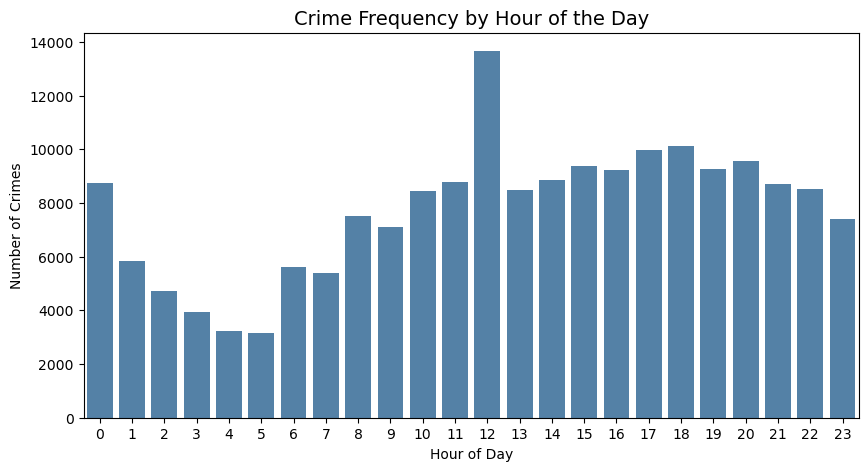

```python
plt.figure(figsize=(10,5))

sns.countplot(data=crimes, x="hour", color="steelblue")

plt.title("Crime Frequency by Hour of the Day", fontsize=14)
plt.xlabel("Hour of Day")
plt.ylabel("Number of Crimes")
plt.show()
```

> **Insight:** Crime frequency peaks at **12 PM (noon)**, indicating a higher concentration of incidents during midday hours. Crime levels are lowest during early morning hours (approximately 2 AM to 5 AM), suggesting reduced activity when fewer people are active.

> This pattern highlights a clear daily trend: crime increases throughout the morning, peaks at midday, and gradually declines in the evening. This insight can support resource allocation by identifying periods of increased crime activity.

## Q2) Which area has the highest frequency of night crimes (10 PM–3:59 AM)?

```python
# .dt.hour - (represents full hour interval) You are grouping time into hourly buckets: 3 → all times between 3:00 and 3:59. No need to check minutes separately.
# for example: "crimes between 10:15 PM and 3:45 AM” or "crimes after 3:30 AM”, then you need hour + minute

crimes_night = crimes[(crimes["hour"] >= 22) | (crimes["hour"] <= 3)]
crimes_night

peak_night_crime_location = crimes_night["area_name"].mode()[0]
peak_night_crime_location
```

```
'Central'
```

### Visualization Using matplotlib - Using Series/Array — Night Crime Frequency by Area

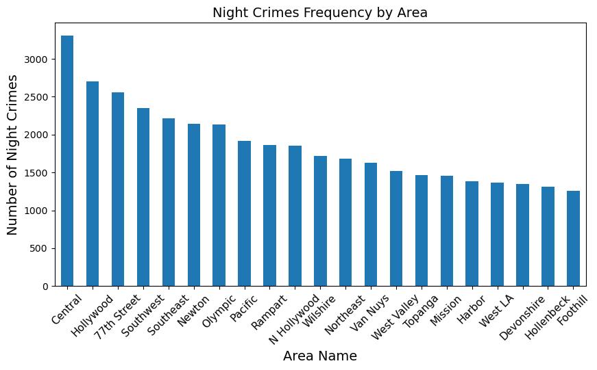

```python
night_crime_counts = crimes_night["area_name"].value_counts()

plt.figure(figsize=(10,5))

night_crime_counts.plot(kind= "bar")

plt.title("Night Crimes Frequency by Area", fontsize=14)
plt.xlabel("Area Name", fontsize=14)
plt.ylabel("Number of Night Crimes", fontsize=14)
plt.xticks(rotation=45, fontsize=11)

plt.show()
```

> **Insight:** The Central area has the highest number of crimes during nighttime hours, followed by areas such as Hollywood and 77th Street. The gradual decline across areas suggests that night crime is concentrated in specific regions rather than evenly distributed across the city.

**Recommendation:** Targeted interventions in high-risk areas like Central may be more effective than city-wide strategies. The concentration of nightlife activities (e.g., entertainment venues and transportation hubs) may contribute to increased exposure and crime risk during nighttime hours.

## Q3) How does crime distribution vary by victim age group?

### Define age bins and labels

```python
bins = [0, 17, 25, 34, 44,54, 64, float("inf")]

labels = ["0-17", "18-25", "26-34", "35-44", "45-54", "55-64", "65+"]
```

### Feature Engineering: Create categorical column for age groups using pd.cut()

```python
crimes["age_group"] = pd.cut(crimes["vict_age"], bins=bins, labels=labels, right=True)
```

### Aggregation — Crime Count by Age Group

```python
crimes.columns
```

```
Index(['dr_no', 'date_rptd', 'date_occ', 'time_occ', 'area_name',
       'crm_cd_desc', 'vict_age', 'vict_sex', 'vict_descent', 'weapon_desc',
       'status_desc', 'location', 'year', 'month', 'month_name', 'day_of_week',
       'hour', 'minute', 'time', 'time_hm', 'age_group'],
      dtype='object')
```

```python
victim_ages = crimes["age_group"].value_counts().sort_index()
victim_ages
```

```
age_group
0-17      4528
18-25    28291
26-34    47470
35-44    42157
45-54    28353
55-64    20169
65+      14747
Name: count, dtype: int64
```

### Visualization using Seaborn (DataFrame + reset_index) — Crime Distribution by Age Group

> This visualization shows how crime incidents are distributed across different victim age groups.

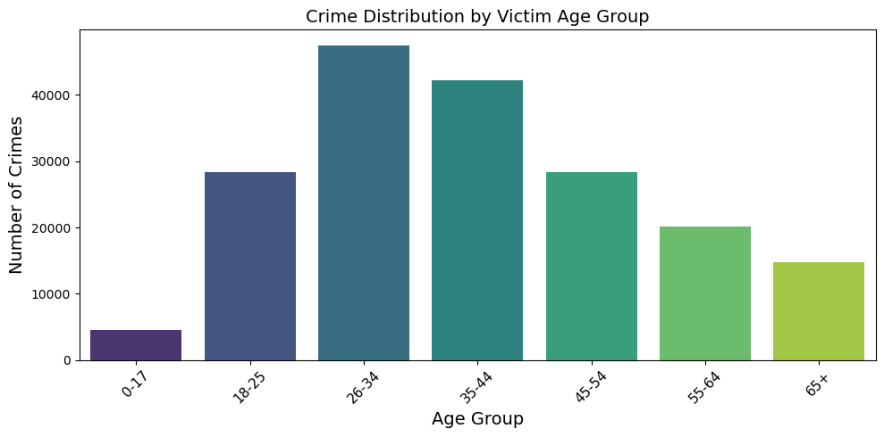

```python
age_df = victim_ages.reset_index(name="count")
age_df.columns = ["age_group", "count"]

plt.figure(figsize=(10, 5))

sns.barplot(
    data=age_df,
    x="age_group",
    y="count",
    palette="viridis",
    hue = "age_group",
    legend = False
)

plt.title("Crime Distribution by Victim Age Group", fontsize=14)
plt.xlabel("Age Group", fontsize=14)
plt.ylabel("Number of Crimes", fontsize=14)
plt.xticks(rotation=45, fontsize=11)
plt.tight_layout()
plt.show()
```

> The plot highlights that the 26–34 age group has the highest number of reported crimes.

> **Insight:** The analysis shows that the **26–34 age group** experiences the highest number of crimes, followed by the **35–44 group**. Crime frequency then gradually decreases for older age groups, with significantly lower counts among individuals aged 65+.

> This pattern suggests that crime incidence is concentrated among young and middle-aged adults, possibly due to higher exposure to public environments, work-related activities, or social interactions.

### Highest Risk Age Group

```python
top_group = crimes["age_group"].value_counts().idxmax()
top_group
```

```
'26-34'
```

> The 26–34 age group has the highest frequency of crimes.

> This insight can support targeted prevention strategies focused on the most affected age groups.

## Q4) What are the top 5 most common crime types?

```python
# value_counts() returns the counts sorted in descending order by default.

type_crimes = crimes["crm_cd_desc"].value_counts()
type_crimes
```

```
crm_cd_desc
THEFT OF IDENTITY                                     22670
BATTERY - SIMPLE ASSAULT                              19694
BURGLARY FROM VEHICLE                                 13799
ASSAULT WITH DEADLY WEAPON, AGGRAVATED ASSAULT        13215
INTIMATE PARTNER - SIMPLE ASSAULT                     11981
                                                      ...
BRIBERY                                                   1
GRAND THEFT / INSURANCE FRAUD                             1
DISRUPT SCHOOL                                            1
FIREARMS EMERGENCY PROTECTIVE ORDER (FIREARMS EPO)        1
LYNCHING                                                  1
Name: count, Length: 104, dtype: int64
```

```python
top_crimes = type_crimes.head(5)
top_crimes
```

```
crm_cd_desc
THEFT OF IDENTITY                                 22670
BATTERY - SIMPLE ASSAULT                          19694
BURGLARY FROM VEHICLE                             13799
ASSAULT WITH DEADLY WEAPON, AGGRAVATED ASSAULT    13215
INTIMATE PARTNER - SIMPLE ASSAULT                 11981
Name: count, dtype: int64
```

### Visualization using Seaborn (DataFrame + reset_index)

> This analysis identifies the most frequent crime types to understand where the majority of incidents are concentrated.

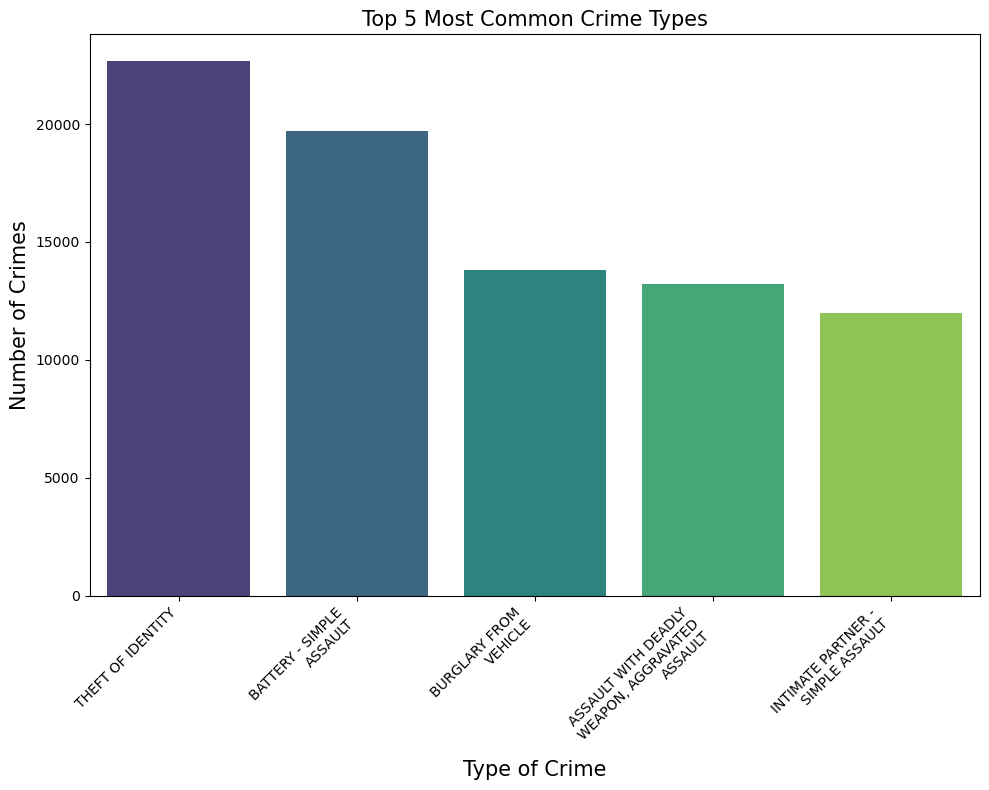

```python
top_common_crimes = top_crimes.reset_index()

top_common_crimes["short_name"] = top_common_crimes["crm_cd_desc"].str.wrap(20)

plt.figure(figsize=(10, 8))


sns.barplot(
    data=top_common_crimes,
    x="short_name",
    y="count",
     hue=top_crimes.index,
     palette="viridis",
    legend=False
)

plt.title("Top 5 Most Common Crime Types", fontsize=15)
plt.xlabel("Type of Crime", fontsize=15)
plt.ylabel("Number of Crimes", fontsize=15)
plt.xticks(rotation=45, ha="right")   # Rotate more

plt.tight_layout()
plt.show()
```

> **Insight:** Theft-related crimes, particularly identity theft, are the most common, followed by battery and assault-related offenses. This indicates that non-violent and low-to-moderate severity crimes occur more frequently than high-severity incidents.

> These patterns suggest that preventive measures such as fraud awareness, property protection, and community-level policing may be effective in reducing overall crime rates. The concentration of incidents within a few crime categories indicates that targeted interventions in these areas could have a significant impact.

## Q5) How does crime distribution vary by victim gender?

### Count

> value_counts() - No includes NaN (missing values are excluded by default)

```python
gender_counts = crimes["vict_sex"].value_counts()
gender_counts
```

```
vict_sex
M    93008
F    89854
X     2812
H       30
Name: count, dtype: int64
```

### Proportions

> value_counts (normalize=True) gives percentages

```python
gender_prop = crimes["vict_sex"].value_counts(normalize=True) * 100      # series
gender_prop
```

```
vict_sex
M    50.084005
F    48.385603
X     1.514238
H     0.016155
Name: proportion, dtype: float64
```

> The presence of this negligible number of ambiguous categories suggests potential data entry inconsistencies. Due to their minimal impact, these values are excluded from the analysis to improve clarity and interpretability.

> The consistency between count-based and proportion-based analyses further reinforces the reliability of these findings.

```python
#  .value_counts(dropna = False) - it counts the missing values / “Do NOT drop missing values”
crimes["vict_sex"].value_counts(dropna=False)
```

```
vict_sex
M      93008
F      89854
X       2812
H         30
NaN       11
Name: count, dtype: int64
```

> The near-equal distribution between male and female victims suggests that crime in this dataset does not disproportionately affect a specific gender. However, the presence of unknown categories highlights the importance of data quality considerations when interpreting demographic patterns.

```python
gender_clean = crimes[crimes["vict_sex"].isin(["M", "F", "X"])]

gender_clean["vict_sex"].value_counts(normalize=True) * 100
```

```
vict_sex
M    50.092097
F    48.393421
X     1.514482
Name: proportion, dtype: float64
```

> Category "H" was removed as it represents less than 0.02% of the data and is undefined, making it unlikely to affect the overall conclusions.

### Visualization using Seaborn (DataFrame + reset_index())

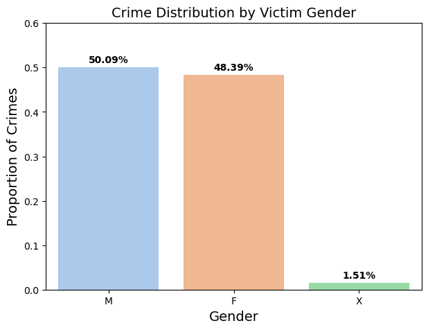

```python
gender_df = gender_clean["vict_sex"].value_counts(normalize=True).reset_index()
gender_df.columns = ["gender", "proportion"]

plt.figure(figsize=(7, 5))

ax = sns.barplot(
    data=gender_df,
    x="gender",
    y="proportion",
    palette="pastel",
    hue="gender"
)


for i, v in enumerate(gender_df["proportion"]):
    ax.text(
        i,
        v + 0.01,
        f"{v:.2%}",
        ha="center",
        fontsize=10,
        fontweight="bold",
        color="black"
    )

plt.title("Crime Distribution by Victim Gender", fontsize=14)
plt.xlabel("Gender", fontsize=14)
plt.ylabel("Proportion of Crimes", fontsize=14)

plt.ylim(0, max(gender_df["proportion"]) + 0.1)

plt.show()
```

> **Insight:** Crime distribution by victim gender is relatively balanced, with male victims representing approximately 50% of cases and female victims around 48%. This suggests that crime in this dataset does not disproportionately affect one gender.

> A small proportion of cases (~1.5%) is categorized as unknown or unspecified, indicating minor data limitations. Overall, the results suggest that crime exposure is broadly distributed across genders rather than concentrated in a specific group.

> From a policy perspective, these findings suggest that crime prevention strategies should be gender-neutral, as both male and female populations are similarly affected. Efforts should focus on overall crime reduction rather than targeting a specific gender group.

## Q6) Which area experiences the highest number of crimes during peak crime hours?

```python
peak_crime_hour = crimes["hour"].value_counts().idxmax()
peak_crime_hour
```

```
12
```

DATA → FILTER → SELECT → COUNT → FIND MAX

```python
# Filter rows
crimes["hour"] == peak_crime_hour

# Apply filter
crime_peak = crimes[crimes["hour"] == peak_crime_hour]   # Apply filter
```

```python
# Select columns and count frequency
area_counts_peak = crime_peak["area_name"].value_counts()

# Get top one
peak_area_peak_hour = area_counts_peak.idxmax()
peak_area_peak_hour
```

```
'Central'
```

### Visualization Using seaborn.barplot() — Series — Top Areas During Peak Crime Hour

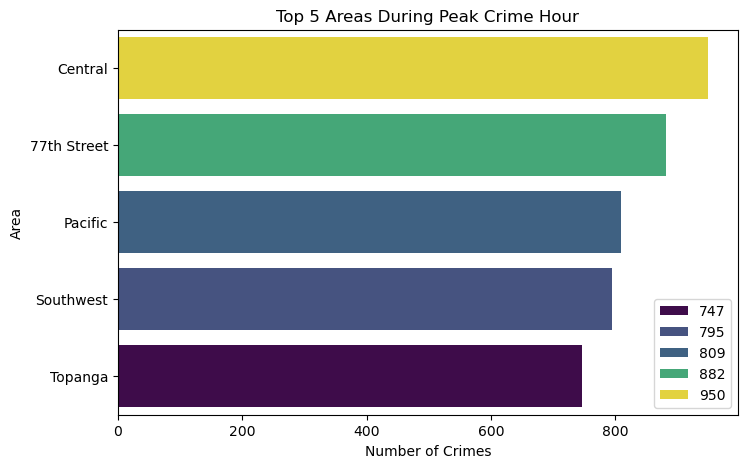

```python
top_areas_peak = area_counts_peak.head(5)

plt.figure(figsize=(8, 5))

sns.barplot(
    x=top_areas_peak.values,
    y=top_areas_peak.index,
    palette="viridis",
    hue = top_areas_peak.values
)

plt.title("Top 5 Areas During Peak Crime Hour")
plt.xlabel("Number of Crimes")
plt.ylabel("Area")

plt.show()
```

> **Insight:** The **Central area** records the highest number of crimes during peak crime hours, reinforcing its position as a high-activity location. This suggests that crime concentration in Central is consistent across both overall trends and peak periods.

> Other areas such as 77th Street and Pacific also show elevated crime levels during peak hours, indicating that crime hotspots remain relatively stable throughout the day.

> These patterns suggest that resource allocation strategies, such as increased patrol presence, could be prioritized in these areas during peak hours to improve effectiveness.

> This result is consistent with previous findings, where Central was also identified as a high-crime area overall.

## Q7) How do crime patterns differ between weekdays and weekends?

### Weekend filter using .isin()

```python
# crimes["day_of_week"].isin(["Saturday","Sunday"]) returns: true, False...

crime_weekend = crimes[crimes["day_of_week"].isin(["Saturday","Sunday"])]
```

### Weekday filter using .isin()

```python
crime_weekdays = crimes[~ crimes["day_of_week"].isin(["Saturday","Sunday"])]
```

### Count

```python
weekend_count = crime_weekend.shape[0]
weekday_count = crime_weekdays.shape[0]
```

### Proportion

```python
total =len(crimes)

weekend_prop = weekend_count/total
weekday_prop = weekday_count/total
```

> In terms of proportions, approximately 71.4% of crimes occur on weekdays, while only about 28.6% occur on weekends, reinforcing the dominance of weekday crime activity.

### Visualization Using seaborn.barplot() — Dataframe — Crime Distribution: Weekdays vs Weekends

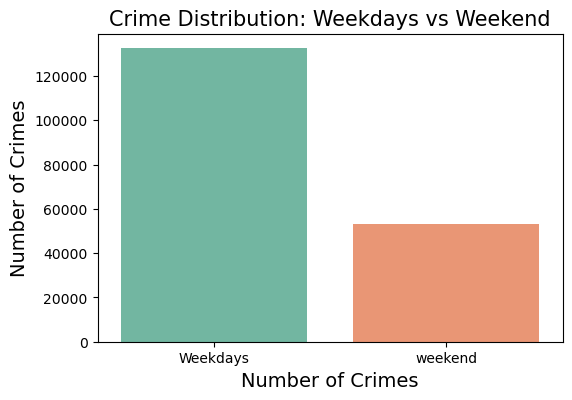

|  | type | count |
| --- | --- | --- |
| 0 | Weekdays | 132530 |
| 1 | weekend | 53185 |

```python
df_week = pd.DataFrame({
    "type":["Weekdays", "weekend"],
    "count": [weekday_count, weekend_count]})

df_week

plt.figure(figsize=(6,4))


sns.barplot( data=df_week,
            x="type",
            y="count",
            hue = "type",
            palette="Set2"
)

plt.title("Crime Distribution: Weekdays vs Weekend", fontsize =15)
plt.ylabel("Number of Crimes", fontsize=14)
plt.xlabel("Number of Crimes", fontsize=14)

plt.show()
df_week
```

## Q8) Which weekday has the highest crime frequency?

```python
crime_weekdays = crimes[~ crimes["day_of_week"].isin(["Saturday","Sunday"])]
```

```python
crime_day = crime_weekdays["day_of_week"].value_counts().sort_values(ascending=False)
type(crime_day)
```

```
pandas.core.series.Series
```

```python
high_crime_day = crime_weekdays["day_of_week"].value_counts().idxmax()
high_crime_day
```

```
'Friday'
```

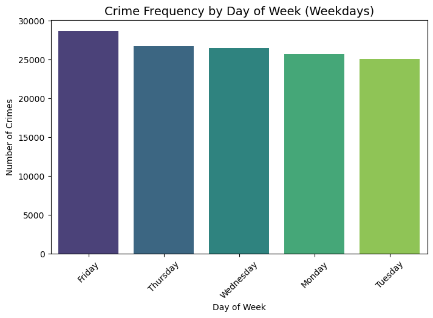

```python
plt.figure(figsize=(8,5))

sns.barplot(
    x=crime_day.index,
    y=crime_day.values,
    palette="viridis",
    hue=crime_day.index

)

plt.title("Crime Frequency by Day of Week (Weekdays)", fontsize=14)
plt.xlabel("Day of Week")
plt.ylabel("Number of Crimes")
plt.xticks(rotation=45)

plt.show()
```

> **Insight:** Crime frequency gradually increases throughout the weekdays, peaking on Friday. This suggests that crime activity may be influenced by end-of-week patterns, such as increased social activity and mobility.

> Earlier weekdays (e.g., Monday and Tuesday) show slightly lower crime levels, indicating a buildup toward the end of the workweek. This trend highlights how routine behavior and weekly cycles can impact crime occurrence.

> From a resource planning perspective, this pattern suggests that law enforcement presence may need to be increased toward the end of the week, particularly on Thursdays and Fridays.

> This pattern is consistent with previous findings, where peak crime hours also aligned with periods of increased activity.

## Q9) How does crime distribution vary by victim descent and gender?

### Group the data

> I use `.size()` when I want to count the number of rows in each group, regardless of missing values. I use `.count()` when I want to count non-null values for specific columns.

```python
gender_clean = crimes[crimes["vict_sex"].isin(["M", "F", "X"])]
```

```python
descent_gender = gender_clean.groupby(["vict_sex", "vict_descent"]).size().reset_index(name="count")
```

### Pivot table

```python
pivot_table = descent_gender.pivot(
                index="vict_descent",
                columns="vict_sex",
                values="count"
)
pivot_table
```

| vict_sex vict_descent | F | M | X |
| --- | --- | --- | --- |
| A | 2663.0 | 2851.0 | 5.0 |
| B | 19762.0 | 15110.0 | 57.0 |
| C | 592.0 | 612.0 | 6.0 |
| D | 11.0 | 10.0 | NaN |
| F | 621.0 | 586.0 | 4.0 |
| G | 7.0 | 7.0 | NaN |
| H | 37683.0 | 36375.0 | 62.0 |
| I | 148.0 | 170.0 | 4.0 |
| J | 211.0 | 221.0 | 1.0 |
| K | 618.0 | 768.0 | 3.0 |
| L | 15.0 | 5.0 | NaN |
| O | 6801.0 | 9501.0 | 28.0 |
| P | 51.0 | 32.0 | NaN |
| S | 10.0 | 6.0 | NaN |
| U | 26.0 | 28.0 | NaN |
| V | 176.0 | 148.0 | 3.0 |
| W | 20100.0 | 24791.0 | 92.0 |
| X | 304.0 | 1696.0 | 2546.0 |
| Z | 54.0 | 90.0 | 1.0 |

### Visualization Using Heatmap — Crime Distribution by Victim Descent and Gender

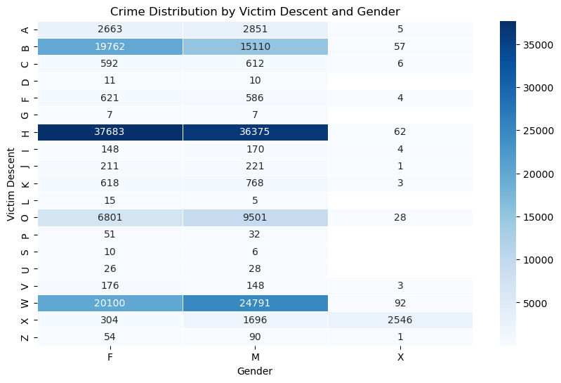

```python
plt.figure(figsize=(10,6))

sns.heatmap(pivot_table, annot=True, fmt=".0f", cmap="Blues", linewidths=0.5)

plt.title("Crime Distribution by Victim Descent and Gender")
plt.xlabel("Gender")
plt.ylabel("Victim Descent")

plt.show()
```

> **Insight:** Crime distribution varies significantly across victim descent and gender, with certain demographic groups experiencing higher concentrations of incidents.

> While both male and female victims are represented across all descent categories, some groups show noticeable imbalances, suggesting that crime exposure is not evenly distributed.

> These patterns may reflect underlying social, economic, or geographic factors influencing crime distribution. However, these differences should be interpreted cautiously, as they may also be affected by reporting practices or the underlying population distribution across groups.

> From an analytical perspective, this highlights the importance of multi-dimensional analysis, as examining gender or descent in isolation may overlook important interaction effects between variables.

> These findings can support more targeted and equitable policy interventions by identifying demographic groups that may be disproportionately affected.

## Q10) How does weapon involvement vary across crime types?

```python
crime_sum = crimes["weapon_desc"].notna().sum()
crime_sum
```

```
73502
```

### Feature creation

```python
crimes["weapon_used"] = crimes["weapon_desc"].notna()
crimes["weapon_used"]
```

```
0         False
1         False
2         False
3         False
4         False
          ...
185710    False
185711    False
185712     True
185713     True
185714    False
Name: weapon_used, Length: 185715, dtype: bool
```

### Overall proportion

```python
weapon_prop= crimes["weapon_used"].value_counts(normalize=True) *100
weapon_prop
```

```
weapon_used
False    60.422152
True     39.577848
Name: proportion, dtype: float64
```

### Visualization using Seaborn.barplot() - (Series/Array) - Proportion of Crimes Involving a Weapon

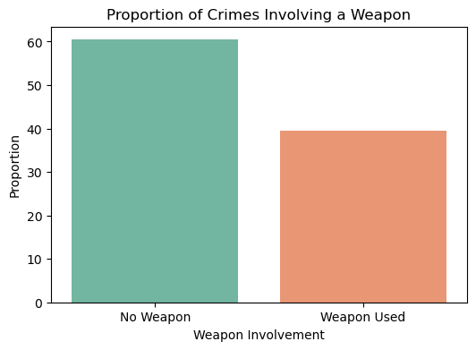

```python
plt.figure(figsize=(6,4))

sns.barplot(
    x=weapon_prop.index,
    y=weapon_prop.values,
    hue= weapon_prop.index,
    legend=False,
    palette="Set2"
)

plt.xticks([0,1], ["No Weapon", "Weapon Used"])
plt.title("Proportion of Crimes Involving a Weapon")
plt.ylabel("Proportion")
plt.xlabel("Weapon Involvement")

plt.show()
```

> **Insight:** The majority of crimes do not involve a weapon, indicating that most incidents are non-violent or involve lower levels of physical threat. However, a significant proportion of crimes still involve weapons, highlighting the presence of more serious and potentially dangerous incidents within the dataset.

> Further analysis shows that certain crime types, such as assault-related offenses, have a higher likelihood of involving weapons, while others rarely involve weapon use. This indicates that weapon involvement is strongly dependent on the type of crime.

> This pattern suggests that crime severity varies significantly across categories, and analyzing weapon involvement provides an additional layer of insight into the nature and risk level of different crimes.

> From a public safety perspective, these findings can help prioritize interventions for high-risk crime types where weapon involvement is more common.

### Crimes with ~100% weapon involvement

```python
weapon_rate = crimes.groupby("crm_cd_desc")["weapon_used"].mean()
always_weapon = weapon_rate[weapon_rate == 1.0]
always_weapon.reset_index(name="weapon_rate")
```

|  | crm_cd_desc | weapon_rate |
| --- | --- | --- |
| 0 | ASSAULT WITH DEADLY WEAPON ON POLICE OFFICER | 1.0 |
| 1 | ASSAULT WITH DEADLY WEAPON, AGGRAVATED ASSAULT | 1.0 |
| 2 | ATTEMPTED ROBBERY | 1.0 |
| 3 | BATTERY - SIMPLE ASSAULT | 1.0 |
| 4 | BATTERY ON A FIREFIGHTER | 1.0 |
| 5 | BATTERY POLICE (SIMPLE) | 1.0 |
| 6 | BOMB SCARE | 1.0 |
| 7 | BRANDISH WEAPON | 1.0 |
| 8 | CRIMINAL HOMICIDE | 1.0 |
| 9 | CRM AGNST CHLD (13 OR UNDER) (14-15 & SUSP 10 ... | 1.0 |
| 10 | DISCHARGE FIREARMS/SHOTS FIRED | 1.0 |
| 11 | INTIMATE PARTNER - AGGRAVATED ASSAULT | 1.0 |
| 12 | KIDNAPPING | 1.0 |
| 13 | KIDNAPPING - GRAND ATTEMPT | 1.0 |
| 14 | LYNCHING | 1.0 |
| 15 | ORAL COPULATION | 1.0 |
| 16 | RESISTING ARREST | 1.0 |
| 17 | ROBBERY | 1.0 |
| 18 | SHOTS FIRED AT INHABITED DWELLING | 1.0 |
| 19 | SHOTS FIRED AT MOVING VEHICLE, TRAIN OR AIRCRAFT | 1.0 |
| 20 | THREATENING PHONE CALLS/LETTERS | 1.0 |
| 21 | WEAPONS POSSESSION/BOMBING | 1.0 |

### Crimes with ~0% weapon involvement

> In contrast, crimes such as identity theft, fraud, and document-related offenses show little to no weapon involvement, reflecting their non-violent nature.

> This clear distinction highlights how weapon involvement is strongly dependent on crime type and serves as an important indicator of crime severity.

```python
low_weapon = weapon_rate[weapon_rate < 0.05]
low_weapon.reset_index(name="weapon_rate")
```

|  | crm_cd_desc | weapon_rate |
| --- | --- | --- |
| 0 | BIGAMY | 0.000000 |
| 1 | BIKE - STOLEN | 0.004490 |
| 2 | BLOCKING DOOR INDUCTION CENTER | 0.000000 |
| 3 | BRIBERY | 0.000000 |
| 4 | BUNCO, ATTEMPT | 0.013333 |
| 5 | BUNCO, GRAND THEFT | 0.009687 |
| 6 | BUNCO, PETTY THEFT | 0.017021 |
| 7 | CONTRIBUTING | 0.000000 |
| 8 | COUNTERFEIT | 0.000000 |
| 9 | CREDIT CARDS, FRAUD USE ($950 & UNDER | 0.032258 |
| 10 | CREDIT CARDS, FRAUD USE ($950.01 & OVER) | 0.000000 |
| 11 | DISHONEST EMPLOYEE - GRAND THEFT | 0.000000 |
| 12 | DISHONEST EMPLOYEE - PETTY THEFT | 0.000000 |
| 13 | DISHONEST EMPLOYEE ATTEMPTED THEFT | 0.000000 |
| 14 | DISRUPT SCHOOL | 0.000000 |
| 15 | DOCUMENT FORGERY / STOLEN FELONY | 0.000000 |
| 16 | DOCUMENT WORTHLESS ($200 & UNDER) | 0.000000 |
| 17 | DOCUMENT WORTHLESS ($200.01 & OVER) | 0.000000 |
| 18 | DRIVING WITHOUT OWNER CONSENT (DWOC) | 0.000000 |
| 19 | EMBEZZLEMENT, GRAND THEFT ($950.01 & OVER) | 0.005682 |
| 20 | EMBEZZLEMENT, PETTY THEFT ($950 & UNDER) | 0.000000 |
| 21 | FAILURE TO YIELD | 0.028846 |
| 22 | FIREARMS EMERGENCY PROTECTIVE ORDER (FIREARMS ... | 0.000000 |
| 23 | GRAND THEFT / INSURANCE FRAUD | 0.000000 |
| 24 | ILLEGAL DUMPING | 0.000000 |
| 25 | PICKPOCKET | 0.011504 |
| 26 | RECKLESS DRIVING | 0.000000 |
| 27 | SHOPLIFTING - ATTEMPT | 0.000000 |
| 28 | SHOPLIFTING - PETTY THEFT ($950 & UNDER) | 0.005025 |
| 29 | SHOPLIFTING-GRAND THEFT ($950.01 & OVER) | 0.006579 |
| 30 | TELEPHONE PROPERTY - DAMAGE | 0.000000 |
| 31 | THEFT FROM MOTOR VEHICLE - ATTEMPT | 0.045198 |
| 32 | THEFT FROM MOTOR VEHICLE - GRAND ($950.01 AND ... | 0.008708 |
| 33 | THEFT FROM MOTOR VEHICLE - PETTY ($950 & UNDER) | 0.018555 |
| 34 | THEFT OF IDENTITY | 0.000088 |
| 35 | THEFT PLAIN - PETTY ($950 & UNDER) | 0.026219 |
| 36 | THEFT, COIN MACHINE - PETTY ($950 & UNDER) | 0.000000 |
| 37 | THEFT-GRAND ($950.01 & OVER)EXCPT,GUNS,FOWL,LI... | 0.032308 |
| 38 | TILL TAP - GRAND THEFT ($950.01 & OVER) | 0.000000 |
| 39 | TILL TAP - PETTY ($950 & UNDER) | 0.000000 |
| 40 | TRESPASSING | 0.035795 |
| 41 | UNAUTHORIZED COMPUTER ACCESS | 0.008547 |
| 42 | VEHICLE, STOLEN - OTHER (MOTORIZED SCOOTERS, B... | 0.007874 |
| 43 | VIOLATION OF COURT ORDER | 0.049338 |
| 44 | VIOLATION OF RESTRAINING ORDER | 0.046588 |

> This comparison demonstrates that analyzing weapon involvement across crime types provides valuable insight into the nature of different offenses, helping distinguish between violent and non-violent crime categories.

> From a public safety perspective, these findings suggest that prevention strategies should be tailored by crime type, with greater focus on reducing weapon access and usage in high-risk violent offenses.

## Appendix — Alternative Approaches and Plots

## Appendix 1 – Alternative Approaches Using .mode() to identify Peak Crime Hour

> This alternative approach identifies the peak crime hour by counting occurrences of each hour and selecting the most frequent one.

```python
# mode()- returns all most frequent values as a Series
# so I use mode()[0] to extract a single value when needed. Statistically correct, handles ties.


# However, I’m aware that there can be multiple modes, so in a production scenario I would check for ties explicitly.

peak_crime_hour = crimes["hour"].mode()[0]
peak_crime_hour
```

```
12
```

### Visualization Using Seaborn.barplot() - Using Series / Arrays — Crime Frequency by Hour

> This visualization shows the distribution of crimes across different hours of the day. By extracting the hour from the time_occ column, we can identify peak periods when crimes occur most frequently.

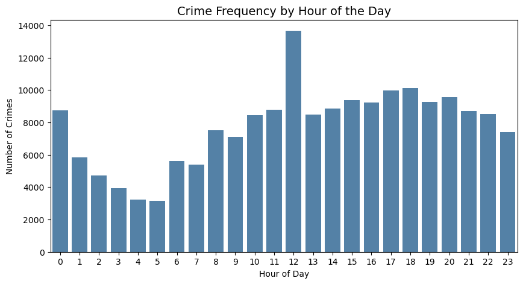

```python
plt.figure(figsize=(10,5))

hour_counts = crimes["hour"].value_counts().sort_index()

sns.barplot(x=hour_counts.index, y=hour_counts.values, color="steelblue")

plt.title("Crime Frequency by Hour of the Day", fontsize=14)
plt.xlabel("Hour of Day")
plt.ylabel("Number of Crimes")
plt.show()
```

## Appendix 2 – Alternative Approaches to Identify Peak Night Crime Area

### Method 1: Aggregation using value_counts()

> value_counts(): counts how many crimes occurred in each area

> idxmax(): returns the area (index) with the highest count

```python
# Count night crimes per area and return the most frequent
# value_counts(): counts how many crimes occurred in each area
# idxmax(): returns the area (index) with the highest count

peak_night_crime_location = crimes["area_name"].value_counts().idxmax()
peak_night_crime_location
```

```
'Central'
```

### Method 2: Time-based filtering using datetime

```python
from datetime import time

# Extract time component for precise comparison
crimes["time"] = crimes["time_occ"].dt.time

# Use OR (|) because the time range crosses midnight (22:00 → 03:59))
crimes_night = crimes[(crimes["time"] >= time(22, 0)) | (crimes["time"] <= time(3, 59))]

# Identify most frequent area
peak_night_crime_location = crimes_night["area_name"].mode()[0]
peak_night_crime_location
```

```
'Central'
```

### Method 3: Visualization Using Seaborn.barplot() - Using Series / Arrays

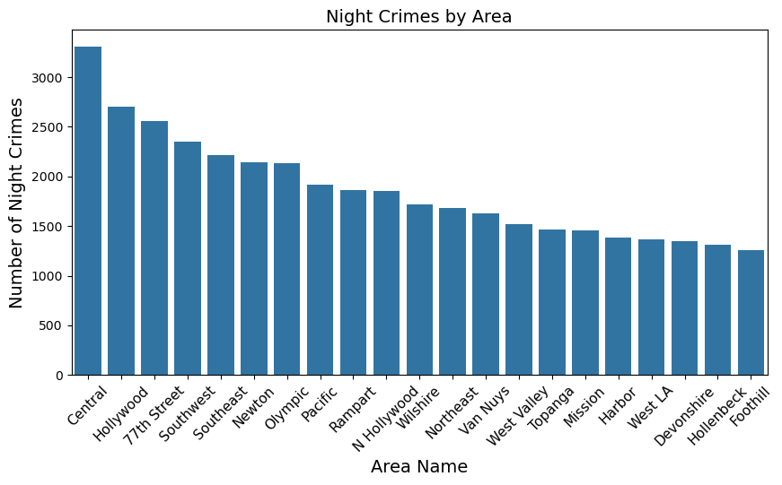

```python
night_crime_counts = crimes_night["area_name"].value_counts()

plt.figure(figsize=(10,5))

sns.barplot(x=night_crime_counts.index,
            y=night_crime_counts.values)

plt.title("Night Crimes by Area", fontsize=14)
plt.xlabel("Area Name", fontsize=14)
plt.ylabel("Number of Night Crimes", fontsize=14)
plt.xticks(rotation=45, fontsize=11)
plt.show()
```

### Method 4: Visualization Using Seaborn.barplot() - Using a DataFrame + reset_index(), Top 5 Areas

> reset_index() - It converts a pandas Series into a DataFrame, allowing easier integration with visualization libraries like seaborn that expect column-based data.

> This approach highlights the top 5 areas with the highest number of night crimes, providing a clearer comparison of high-risk regions.

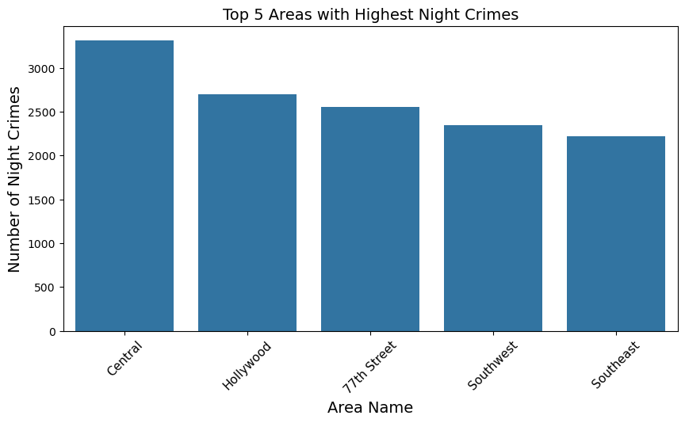

```python
night_crime_counts = crimes_night["area_name"].value_counts().reset_index()

night_crime_counts.columns = ["area_name", "count"]

top5 = night_crime_counts.head(5)


plt.figure(figsize=(10,5))

sns.barplot(data=top5, x= "area_name", y= "count")

plt.title("Top 5 Areas with Highest Night Crimes", fontsize=14)
plt.xlabel("Area Name", fontsize=14)
plt.ylabel("Number of Night Crimes", fontsize=14)
plt.xticks(rotation=45, fontsize=11)
plt.show()
```

> The visualization clearly shows that Central has the highest number of night crimes, significantly exceeding other areas. This reinforces the results obtained through aggregation methods.

> All methods consistently identify the Central area as having the highest frequency of night crimes, reinforcing the reliability and robustness of the analysis.

## Appendix 3 – Alternative Approaches to identify the Most Affected Age Group

### Method 1: This approach groups records by age_group and uses .size() to count the number of crimes in each category including missing values.

> pd.cut() creates the categorical age ranges (it is used to turn a continuous numeric variable into interval-based categories.)

> groupby("age_group") groups rows by those ranges

> .size() counts how many crimes fall in each group,

> .size() counts all rows in each group, including missing values.

> Aggregation using groupby() and size()

```python
# Define bins and labels
bins = [0, 17, 25, 34, 44, 54, 64, float("inf")]
labels = ["0-17", "18-25", "26-34", "35-44", "45-54", "55-64", "65+"]


# pd.cut() - It takes numeric values and places each value into a bin.
# Create age group column
crimes["age_group"] = pd.cut(crimes["vict_age"], bins=bins, labels=labels, include_lowest=True)


# Alternative approach using groupby()
victim_ages = crimes.groupby("age_group", observed=False).size().reindex(labels)

victim_ages
```

```
age_group
0-17      4528
18-25    28291
26-34    47470
35-44    42157
45-54    28353
55-64    20169
65+      14747
dtype: int64
```

### Method 2:This approach groups records by age_group and uses .count() to count only the non-null values for the number of crimes in each category.

> pd.cut() creates the categorical age ranges (it is used to turn a continuous numeric variable into interval-based categories.)

> groupby("age_group") groups rows by those ranges

> .count() counts non-null values in a specific column, while .size() counts all rows.

> Aggregation using groupby() and count()

```python
# .count() counts only non-null values in a specific column. For counting
comparison = pd.DataFrame({
    "size": crimes.groupby("age_group").size(),
    "count_vict_age": crimes.groupby("age_group")["vict_age"].count()
})

comparison
```

| age_group | size | count_vict_age |
| --- | --- | --- |
| 0-17 | 4528 | 4528 |
| 18-25 | 28291 | 28291 |
| 26-34 | 47470 | 47470 |
| 35-44 | 42157 | 42157 |
| 45-54 | 28353 | 28353 |
| 55-64 | 20169 | 20169 |
| 65+ | 14747 | 14747 |

> Both **.size()** and **.count()** can be used for aggregation. However, **.size() counts all records including missing values**, while **.count() excludes missing values** in the selected column.

### Method 3: Visualization using Seaborn.barplot() (Series-based input)

> This visualization provides a clear comparison of crime counts across age groups.

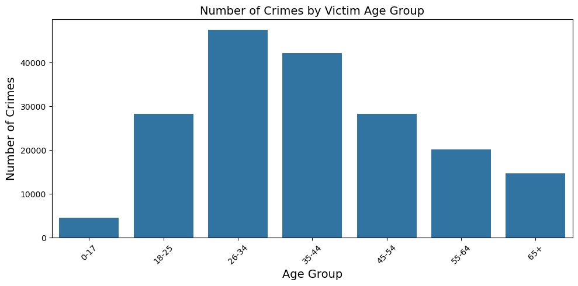

```python
plt.figure(figsize=(10,5))

sns.barplot(x = victim_ages.index, y = victim_ages.values)

plt.title("Number of Crimes by Victim Age Group", fontsize=14)
plt.xlabel("Age Group", fontsize=14)
plt.ylabel("Number of Crimes", fontsize=14)
plt.xticks(rotation=45)
plt.tight_layout()

plt.show()
```

### Method 4 : Visualization Using Seaborn.barplot() - (DataFrame + reset_index)

> This approach converts the Series into a structured DataFrame using reset_index(), making it more compatible with Seaborn and improving code readability.

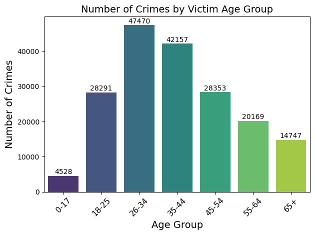

```python
ax = sns.barplot(
    data=age_df,
    x="age_group",
    y="count",
    hue="age_group",
    palette="viridis",
    legend=False
)

for i, v in enumerate(age_df["count"]):
    ax.text(i, v + 500, str(v), ha='center')


plt.title("Number of Crimes by Victim Age Group", fontsize=14)
plt.xlabel("Age Group", fontsize=14)
plt.ylabel("Number of Crimes", fontsize=14)
plt.xticks(rotation=45, fontsize=11)
plt.tight_layout()
plt.show()

plt.show()
```

### Method 5 : Identifying the highest group using - .loc[] and .idxmax()

> This method identifies the age group with the highest number of crimes using .idxmax() on aggregated counts.

```python
# age_df["count"].idxmax() → gives row index of max value

# .loc[...] → selects that row

# "age_group" → returns the label


top_group = age_df.loc[age_df["count"].idxmax(), "age_group"]
top_group
```

```
'26-34'
```

### Final Insight

> The 26–34 age group consistently experiences the highest number of crimes. This suggests that working-age adults are more exposed to crime, likely due to higher levels of mobility, social interaction, and time spent in public environments.

> Using multiple approaches ensures that results are not dependent on a single method and increases confidence in the findings.

## Appendix 4 – Alternative Approaches to Identify the Top5 Most Common Crime Types

### Method 1 : Visualization Using Seaborn.barplot() - (DataFrame + reset_index)

> This visualization compares the frequency of the top 5 crime types, highlighting the most common offenses.

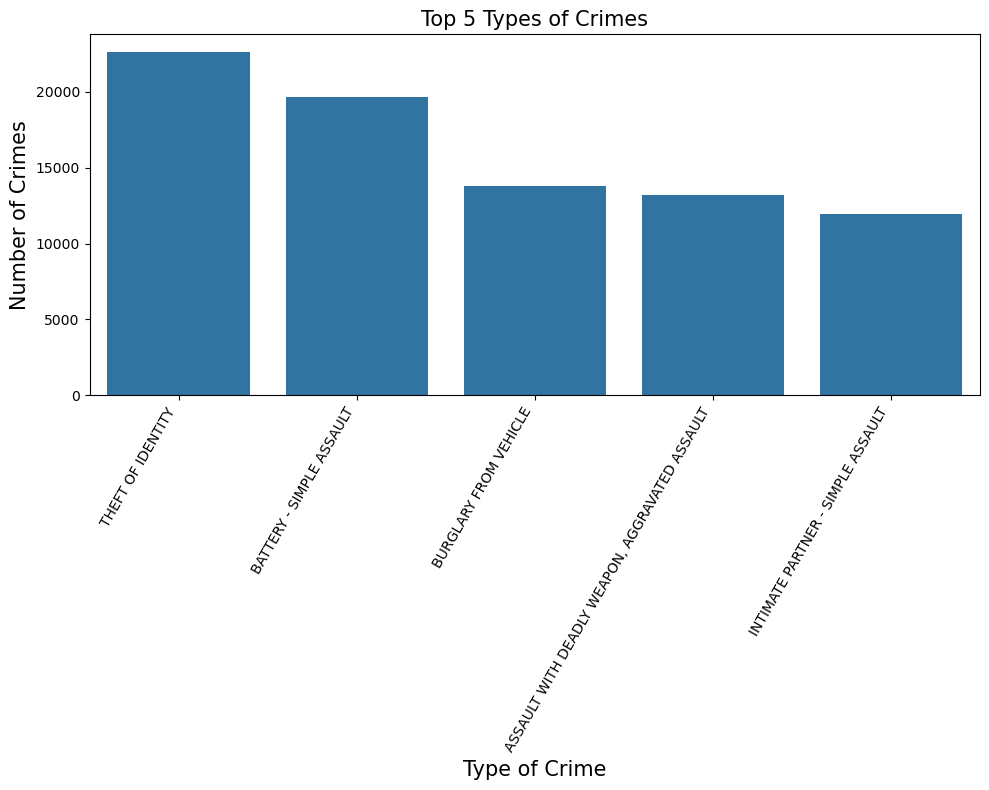

```python
top_common_crimes = top_crimes.reset_index()

top_common_crimes.columns = ["crm_cd_desc", "count"]

plt.figure(figsize=(10, 8))

sns.barplot(
    data=top_common_crimes,
    x="crm_cd_desc",
    y="count"
)

plt.title("Top 5 Types of Crimes", fontsize=15)
plt.xlabel("Type of Crime", fontsize=15)
plt.ylabel("Number of Crimes", fontsize=15)
plt.xticks(rotation=60, ha="right", fontsize=10)
plt.tight_layout()

plt.show()
```

### Method 2 : Visualization Using Seaborn.barplot() (Series)

> This visualization compares the frequency of the top 5 crime types, highlighting the most common offenses.

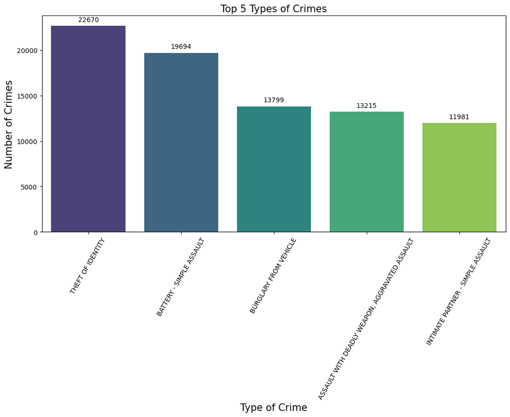

```python
plt.figure(figsize=(11,9))

ax= sns.barplot(x = top_crimes.index,
            y = top_crimes.values,
            hue=top_crimes.index,
            palette="viridis",
            legend=False
)

for i, v in enumerate(top_crimes.values):
    ax.text(i, v + 500, str(v), ha='center')

ax.set_title("Top 5 Types of Crimes", fontsize=15)
ax.set_xlabel("Type of Crime", fontsize=15)
ax.set_ylabel("Number of Crimes", fontsize=15)
ax.tick_params(axis='x', rotation=60)

#ax.tick_param(rotation=60, ha="right")

plt.tight_layout()

plt.show()
```

### Method 3: Visualization using matplotlib (plt.bar) (Series)

> This visualization compares the frequency of the top 5 crime types, highlighting the most common offenses.

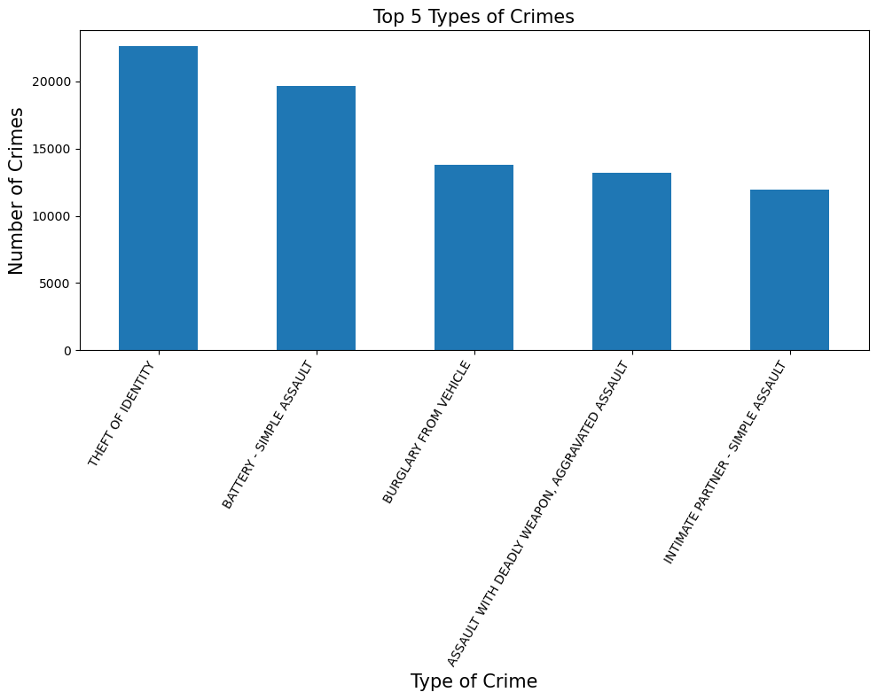

```python
plt.figure(figsize=(10, 8))

top_crimes.plot(kind= "bar", x= "crm_cd_desc", y= "count") # If you want to control x and y explicitly


plt.title("Top 5 Types of Crimes", fontsize=15)
plt.xlabel("Type of Crime", fontsize=15)
plt.ylabel("Number of Crimes", fontsize=15)
plt.xticks(rotation=60, ha="right")

plt.tight_layout()
plt.show()
```

> Theft-related crimes, particularly identity theft, are the most frequent, followed by battery and assault-related offenses. This indicates that both property crimes and violent incidents play a significant role in overall crime patterns.

> All methods consistently identify the same top 5 crime types, confirming the reliability and robustness of the analysis.

**Final Insight:** Theft-related crimes dominate the dataset, indicating that non-violent and lower-severity incidents occur more frequently than high-severity crimes. This suggests that targeted prevention strategies—such as fraud awareness and property protection—could significantly reduce overall crime levels.

> Using multiple visualization approaches ensures that results are consistent and not dependent on a single plotting method.

## Appendix 5 — Alternative Approaches to Analyze Crime Distribution by Victim Gender

### Method 1 : Visualization Using Seaborn.barplot() (Using Series/Array)

> This alternative approach calculates the proportion of crimes by victim gender using a Series-based method and visualizes the results with a bar plot.

> The results are consistent with the main analysis, showing a near-equal distribution between male and female victims, along with a small proportion of unknown values.

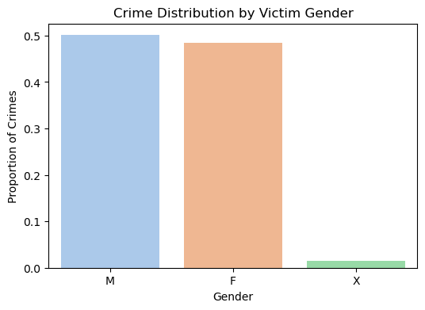

```python
gender = gender_clean["vict_sex"].value_counts(normalize=True)

plt.figure(figsize=(6, 4))

sns.barplot( x= gender.index,
             y= gender.values,
             palette="pastel",
             hue = gender.index,
             legend = False

)

plt.title("Crime Distribution by Victim Gender")
plt.ylabel("Proportion of Crimes")
plt.xlabel("Gender")

plt.show()
```

## Appendix 7 — Alternative Approach to Analyze Weekday vs Weekend Crime Distribution

#### Method: Using value_counts(normalize=True)

> This alternative approach computes the proportion of crimes occurring on weekdays and weekends using a more concise pandas method. .map() was used to convert boolean values into meaningful categorical labels, making the data easier to interpret and visualize.

```python
# isin(["Saturday", "Sunday"]) checks: If the day is Saturday or Sunday → True, Otherwise → False
crimes["day_type"] = crimes["day_of_week"].isin(["Saturday", "Sunday"])

crimes["day_type"] = crimes["day_type"].map({True: "Weekend", False: "Weekday"})

crimes["day_type"].value_counts(normalize=True) * 100
```

```
day_type
Weekday    71.362033
Weekend    28.637967
Name: proportion, dtype: float64
```

Back to top